# Summary figures for all SOM event yield results

Dustin Kincaid

04/26/2021

### Objective

##### Create key figures for paper summarizing all results of SOM clustered flux regimes on event water, NO3, SRP, and turbidity yields from Hungerford and Wade Brooks. Note: these current figures assume that the best SOM model for every site X variable combo has 5 clusters. This seems to often be the case, but I have not yet evaluated every site X variable combo. Also note that these figures are not in their final format.

### Feedback request

##### I’m mainly looking for ways to frame this story about the influence of watershed conditions and event characteristics on yields from the two catchments with different primary land uses. I am also looking for suggestions for different analyses and/or ways to visualize the data. All other general feedback is welcome as well.

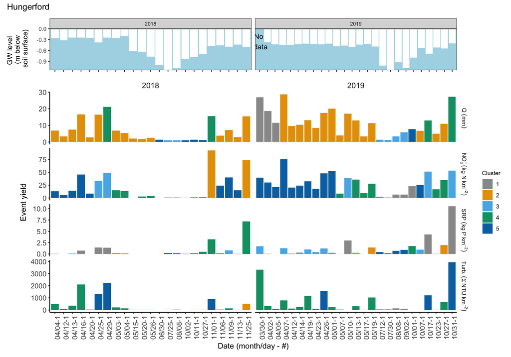

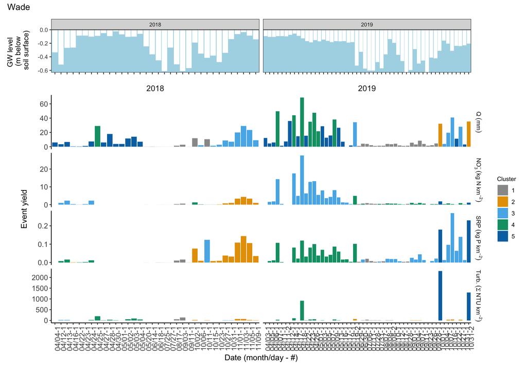

Time series of water yields colored by cluster. 2017 data not shown because only a few events in fall. The white bars in the upper groundwater level plot indicate the groundwater depth below the soil surface. Keep in mind that a different SOM was created for each site x variable (e.g., NO3, SRP) combo; thus, the clusters may not have the same properties for each site x variable combination.

##### Ice-free season yields attributed to each cluster

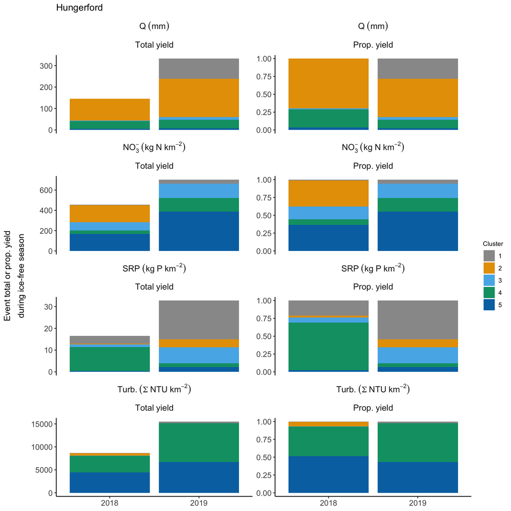

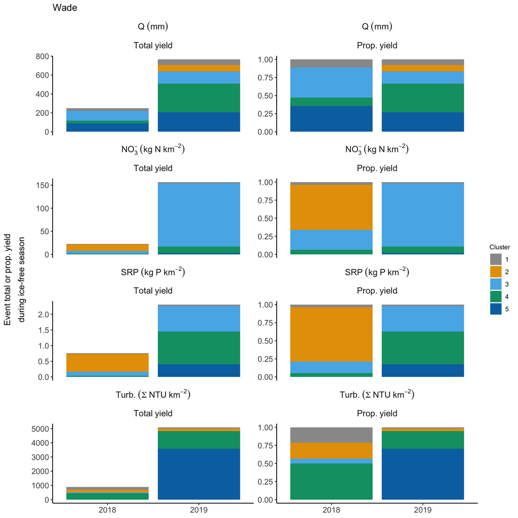

Total ice-free season water yield attributed to each cluster. Keep in mind that a different SOM was created for each site x variable (e.g., NO3, SRP) combo; thus, the clusters may not have the same properties for each site x variable combination.

##### Relationship between event NO3, SRP, or turbidity yield and event water yield for each season

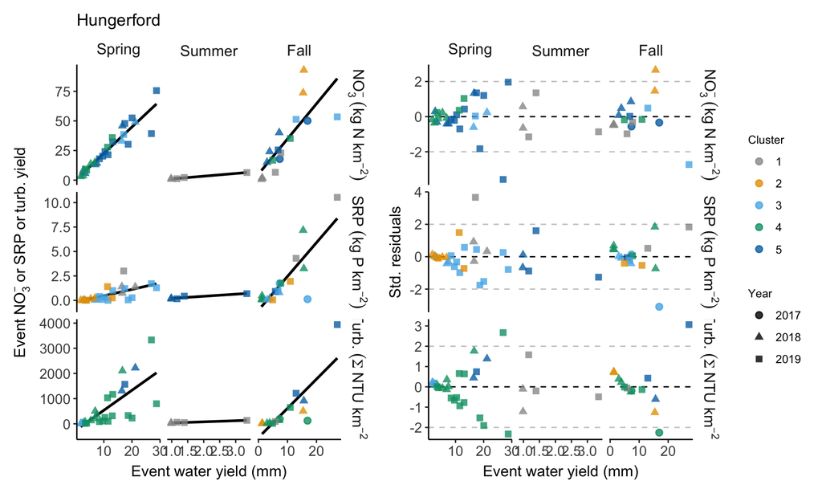

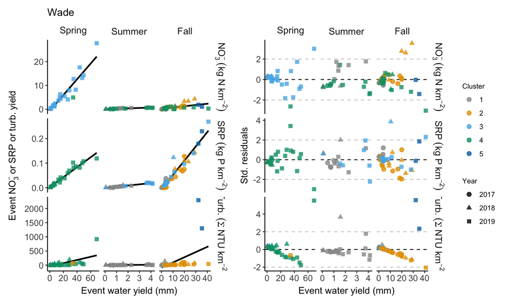

Need to remove outliers from regressions.

##### Event NO3 to SRP yield ratios

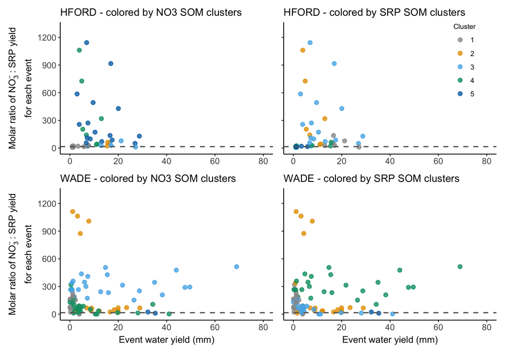

Molar ratio of NO3 to SRP yield for each event. The dashed horizontal line shows the 16:1 molar N:P ratio.